# BMIN503 Final Project Methods

### Multiple imputation

- Used mice function to impute missing data values

```r
impute <- mice(nhanesDataFull[,2:34], m=5, seed=619)
```

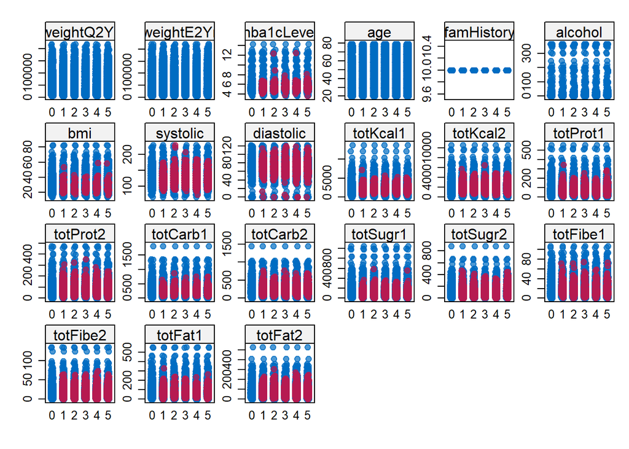

```r
stripplot(impute, pch=20, cex=1.2)
```

```r
library(mice)

impute1 <- mice::complete(impute, 1)
impute2 <- mice::complete(impute, 2)
impute3 <- mice::complete(impute, 3)
impute4 <- mice::complete(impute, 4)
impute5 <- mice::complete(impute, 5)
imputeLong <- mice::complete(impute, "long", inc=FALSE)

imputeLong <- subset(imputeLong, select=-c(.imp))
imputeLong <- subset(imputeLong, select=-c(.id))


impute1 <- impute1 %>%
  mutate(hba1cCutoff = ifelse(hba1cLevel<6.5, 0, 1)) %>%
  mutate(totKcal=(totKcal1+totKcal2)/2) %>%
  mutate(totProt=(totProt1 + totProt2)/2) %>%
  mutate(totCarb=(totCarb1+totCarb2)/2) %>%
  mutate(totSugr=(totSugr1+totSugr2)/2) %>%
  mutate(totFibe=(totFibe1+totFibe2)/2) %>%
  mutate(totFat=(totFat1+totFat2)/2)

imputeLong <- imputeLong %>%
  mutate(hba1cCutoff = ifelse(hba1cLevel<6.5, 0, 1))  %>%
  mutate(totKcal=(totKcal1+totKcal2)/2) %>%
  mutate(totProt=(totProt1 + totProt2)/2) %>%
  mutate(totCarb=(totCarb1+totCarb2)/2) %>%
  mutate(totSugr=(totSugr1+totSugr2)/2) %>%
  mutate(totFibe=(totFibe1+totFibe2)/2) %>%
  mutate(totFat=(totFat1+totFat2)/2)

impute1 <- impute1 %>%
  mutate(hba1cCutoffFactor = factor(hba1cCutoff, levels=c("0","1"), labels=c("no", "yes")))
#"no" = no undiagnosed diabetes (<6.5), "yes" = undiagnosed diabetes (>6.5)

imputeLong <- imputeLong %>%
  mutate(hba1cCutoffFactor = factor(hba1cCutoff, levels=c("0","1"), labels=c("no", "yes")))

#table(imputeLong$hba1cCutoff)
```

## Bivariate Analyses

- Chi square test and ANOVA conducted on categorical and continuous variables, respectively.
- Bivariate analyses were conducted to identify signifcant factors to then use in regression and radom forest models
- Significant in bivariate analyses: age + race + education + PIR + bmi + insurance + foodSecure + totKcal + totProt + totCarb + totSugr + totFat + diet

### Factors significant in Bivariate Analysis:

Demographic Factors * Age – (p<0.001) * Race - 4% of undiagnosed adults who were non-Hispanic Black or Other Hispanic had high HbA1c Levels (p<0.001) * Education - (p<0.001) * Income - between 133-149% of the poverty line had the highest proportion of high HbA1c levels (5%), compared to 2% among those with the incomes below the poverty line (p<0.001) * Not significant - Gender, marital status

```r
#chisqAgeCut <- {weights::wtd.chi.sq(impute1$hba1cCutoff, impute1$ageCut, weight=imputeLong$weightE2Yr)}
chisqAge <- summary(aov(age ~ hba1cCutoff, data=impute1))
chisqGender <- {weights::wtd.chi.sq(impute1$hba1cCutoff, impute1$gender, weight=impute1$weightE2Yr)}
chisqRace <- {weights::wtd.chi.sq(impute1$hba1cCutoff, impute1$race, weight=impute1$weightE2Yr)}
chisqEd <- {weights::wtd.chi.sq(impute1$hba1cCutoff, impute1$education, weight=impute1$weightE2Yr)}
chisqPir <- {weights::wtd.chi.sq(impute1$hba1cCutoff, impute1$PIR, weight=impute1$weightE2Yr)}
chisqBmi <- summary(aov(bmi ~ hba1cCutoff, data=imputeLong))
chisqFamHist <- {weights::wtd.chi.sq(impute1$hba1cCutoff, impute1$famHist, weight=impute1$weightE2Yr)}
chisqInsurance <- {weights::wtd.chi.sq(impute1$hba1cCutoff, impute1$insurance, weight=impute1$weightE2Yr)}
chisqMar <- {weights::wtd.chi.sq(impute1$hba1cCutoff, impute1$marital, weight=impute1$weightE2Yr)}
chisqFood <- {weights::wtd.chi.sq(impute1$hba1cCutoff, impute1$foodSecure, weight=impute1$weightE2Yr)}
chisqSmoke <- {weights::wtd.chi.sq(impute1$hba1cCutoff, impute1$smoke, weight=impute1$weightE2Yr)}
chisqAlcohol <- summary(aov(alcohol ~ hba1cCutoff, data=imputeLong))
chisqDiet <- {weights::wtd.chi.sq(impute1$hba1cCutoff, impute1$diet, weight=impute1$weightE2Yr)}
chisqSnap <- {weights::wtd.chi.sq(impute1$hba1cCutoff, impute1$snapCurrent, weight=impute1$weightE2Yr)}

#Nutrient factors
chisqKcal <- summary(aov(totKcal ~ hba1cCutoff, data=impute1))
chisqProt <- summary(aov(totProt ~ hba1cCutoff, data=impute1))
chisqCarb <- summary(aov(totCarb ~ hba1cCutoff, data=impute1))
chisqSugr <- summary(aov(totSugr ~ hba1cCutoff, data=impute1))
chisqFibe <- summary(aov(totFibe ~ hba1cCutoff, data=impute1))
chisqFat <-  summary(aov(totFat ~ hba1cCutoff, data=impute1))
```

## Linear Regression

- testing out linear regression, but decided not to include

```r
nhanesLm1 <- lm(data=impute1, hba1cLevel ~ age + race + education + PIR + bmi + insurance + foodSecure + totKcal + totProt + totCarb + totSugr + totFat + diet)
summary(nhanesLm1)
```

```
##
## Call:
## lm(formula = hba1cLevel ~ age + race + education + PIR + bmi +
##     insurance + foodSecure + totKcal + totProt + totCarb + totSugr +
##     totFat + diet, data = impute1)
##
## Residuals:
##     Min      1Q  Median      3Q     Max
## -2.0674 -0.2493 -0.0183  0.2003  8.4166
##
## Coefficients:
##                        Estimate Std. Error t value Pr(>|t|)
## (Intercept)           4.392e+00  5.069e-02  86.640  < 2e-16 ***
## age                   1.128e-02  4.327e-04  26.080  < 2e-16 ***
## raceblack             1.638e-01  1.709e-02   9.585  < 2e-16 ***
## raceMexA              9.804e-02  2.284e-02   4.292 1.80e-05 ***
## raceAsian             2.271e-01  2.364e-02   9.607  < 2e-16 ***
## raceHispanic          1.124e-01  2.354e-02   4.775 1.83e-06 ***
## raceother             1.107e-01  3.673e-02   3.013 0.002598 **
## educationhigh        -4.225e-02  2.098e-02  -2.013 0.044123 *
## educationsomecollege -8.837e-02  2.001e-02  -4.416 1.02e-05 ***
## educationcollege     -1.004e-01  2.250e-02  -4.463 8.22e-06 ***
## PIR1-1.32             3.821e-02  2.383e-02   1.603 0.108888
## PIR1.33-1.49         -5.187e-03  3.651e-02  -0.142 0.887047
## PIR1.5-1.84          -2.226e-02  2.825e-02  -0.788 0.430709
## PIR1.85-5.0          -5.024e-03  1.874e-02  -0.268 0.788695
## bmi                   1.538e-02  1.005e-03  15.301  < 2e-16 ***
## insuranceno           6.667e-02  1.625e-02   4.104 4.11e-05 ***
## foodSecuremarginal    1.325e-02  2.143e-02   0.618 0.536471
## foodSecurelow         4.662e-02  2.263e-02   2.060 0.039425 *
## foodSecureverylow     7.629e-02  2.497e-02   3.055 0.002262 **
## totKcal              -1.632e-04  4.060e-05  -4.021 5.87e-05 ***
## totProt               5.770e-04  3.202e-04   1.802 0.071628 .
## totCarb               7.993e-04  2.309e-04   3.461 0.000541 ***
## totSugr              -9.934e-05  2.054e-04  -0.484 0.628652
## totFat                1.770e-03  4.531e-04   3.908 9.41e-05 ***
## dietverygood          1.965e-02  2.624e-02   0.749 0.453829
## dietgood              5.139e-02  2.450e-02   2.098 0.035974 *
## dietfair              5.515e-02  2.699e-02   2.044 0.041020 *
## dietpoor              3.455e-02  3.667e-02   0.942 0.346148
## ---
## Signif. codes:  0 '***' 0.001 '**' 0.01 '*' 0.05 '.' 0.1 ' ' 1
##
## Residual standard error: 0.522 on 6605 degrees of freedom
## Multiple R-squared:  0.1684, Adjusted R-squared:  0.165
## F-statistic: 49.55 on 27 and 6605 DF,  p-value: < 2.2e-16
```

## Logistic Regression

- Logistic regression conducted with HbA1c above or below 6.5 as the outcome and features in the model were: age, race, education, PIR, bmi, insurance, foodSecure, totKcal, totProt, totCarb, totSugr, totFat, diet.

### Results of Logistic REgression

```r
#checking hba1ccutoff variable and found it was character
summary(impute1$hba1cCutoff)
```

```
##    Min. 1st Qu.  Median    Mean 3rd Qu.    Max.
## 0.00000 0.00000 0.00000 0.02533 0.00000 1.00000
```

```r
class(impute1$hba1cCutoff)
```

```
## [1] "numeric"
```

```r
options(scipen=999) #prevents ORs from being in scientific notation. 999 sets a high threshold for R to use scientific notation

#logistic regression
nhanesGlm <- glm(impute1$hba1cCutoffFactor ~ age + race + education + PIR + bmi + insurance + foodSecure + totKcal + totProt + totCarb + totSugr + totFat + diet, data = impute1, family = binomial(logit))
summary(nhanesGlm)
```

```
##
## Call:
## glm(formula = impute1$hba1cCutoffFactor ~ age + race + education +
##     PIR + bmi + insurance + foodSecure + totKcal + totProt +
##     totCarb + totSugr + totFat + diet, family = binomial(logit),
##     data = impute1)
##
## Deviance Residuals:
##     Min       1Q   Median       3Q      Max
## -2.2093  -0.2323  -0.1466  -0.0911   3.2746
##
## Coefficients:
##                         Estimate  Std. Error z value             Pr(>|z|)
## (Intercept)          -10.7523711   0.7743729 -13.885 < 0.0000000000000002 ***
## age                    0.0561902   0.0063070   8.909 < 0.0000000000000002 ***
## raceblack              1.1808274   0.2286575   5.164       0.000000241501 ***
## raceMexA               0.9262727   0.2964812   3.124              0.00178 **
## raceAsian              2.0399434   0.3177570   6.420       0.000000000136 ***
## raceHispanic           1.2073283   0.2953914   4.087       0.000043658112 ***
## raceother              0.7189765   0.5368657   1.339              0.18050
## educationhigh         -0.0026625   0.2281543  -0.012              0.99069
## educationsomecollege  -0.1900053   0.2332140  -0.815              0.41523
## educationcollege      -0.4578604   0.2902654  -1.577              0.11471
## PIR1-1.32              0.5654851   0.2609508   2.167              0.03023 *
## PIR1.33-1.49           0.4507932   0.3843435   1.173              0.24084
## PIR1.5-1.84           -0.0451222   0.3422479  -0.132              0.89511
## PIR1.85-5.0           -0.0288647   0.2403372  -0.120              0.90440
## bmi                    0.0876000   0.0097157   9.016 < 0.0000000000000002 ***
## insuranceno            0.3264765   0.2002705   1.630              0.10306
## foodSecuremarginal     0.2935464   0.2465230   1.191              0.23375
## foodSecurelow          0.0131159   0.2696133   0.049              0.96120
## foodSecureverylow      0.4299186   0.2926731   1.469              0.14185
## totKcal               -0.0004712   0.0006884  -0.685              0.49366
## totProt                0.0045315   0.0047827   0.947              0.34340
## totCarb                0.0007941   0.0035236   0.225              0.82169
## totSugr                0.0006522   0.0028989   0.225              0.82198
## totFat                 0.0042506   0.0072296   0.588              0.55657
## dietverygood           0.2396848   0.4228829   0.567              0.57086
## dietgood               0.6791478   0.3838441   1.769              0.07684 .
## dietfair               0.6741648   0.4072600   1.655              0.09785 .
## dietpoor               0.4865069   0.5115790   0.951              0.34161
## ---
## Signif. codes:  0 '***' 0.001 '**' 0.01 '*' 0.05 '.' 0.1 ' ' 1
##
## (Dispersion parameter for binomial family taken to be 1)
##
##     Null deviance: 1566.8  on 6632  degrees of freedom
## Residual deviance: 1307.3  on 6605  degrees of freedom
## AIC: 1363.3
##
## Number of Fisher Scoring iterations: 7
```

```r
exp(cbind(OR = coef(nhanesGlm), confint(nhanesGlm)))
```

```
##                                 OR          2.5 %         97.5 %
## (Intercept)          0.00002139462 0.000004492566  0.00009393096
## age                  1.05779883641 1.045024833523  1.07121044972
## raceblack            3.25706787827 2.094355182183  5.14781371962
## raceMexA             2.52507987330 1.400299674821  4.49831882173
## raceAsian            7.69017427812 4.093711862749 14.29833315732
## raceHispanic         3.34453702824 1.855766339707  5.93913681895
## raceother            2.05233167442 0.626848851005  5.35065476897
## educationhigh        0.99734106033 0.636632040928  1.56050451274
## educationsomecollege 0.82695472438 0.522977828604  1.30734118897
## educationcollege     0.63263575718 0.354905355392  1.11085371732
## PIR1-1.32            1.76030151674 1.050593043135  2.93284832215
## PIR1.33-1.49         1.56955666247 0.703726673907  3.21975444689
## PIR1.5-1.84          0.95588063417 0.472250400414  1.82477684502
## PIR1.85-5.0          0.97154786350 0.609800751505  1.56718592599
## bmi                  1.09155136702 1.070913583366  1.11253683058
## insuranceno          1.38607563541 0.930191038657  2.04248464114
## foodSecuremarginal   1.34117540262 0.812344174491  2.14263558417
## foodSecurelow        1.01320228823 0.583294993838  1.68644025922
## foodSecureverylow    1.53713234016 0.845884259884  2.67774570261
## totKcal              0.99952890486 0.998069860812  1.00076838290
## totProt              1.00454175126 0.995199119489  1.01405717623
## totCarb              1.00079446438 0.994113885186  1.00797631949
## totSugr              1.00065245966 0.994970193799  1.00634299413
## totFat               1.00425968261 0.990808824503  1.01935284887
## dietverygood         1.27084845545 0.576902924263  3.09577684952
## dietgood             1.97219633459 0.985767989638  4.52543247381
## dietfair             1.96239336509 0.928437957719  4.67336474941
## dietpoor             1.62662428103 0.595976695227  4.55373398918
```

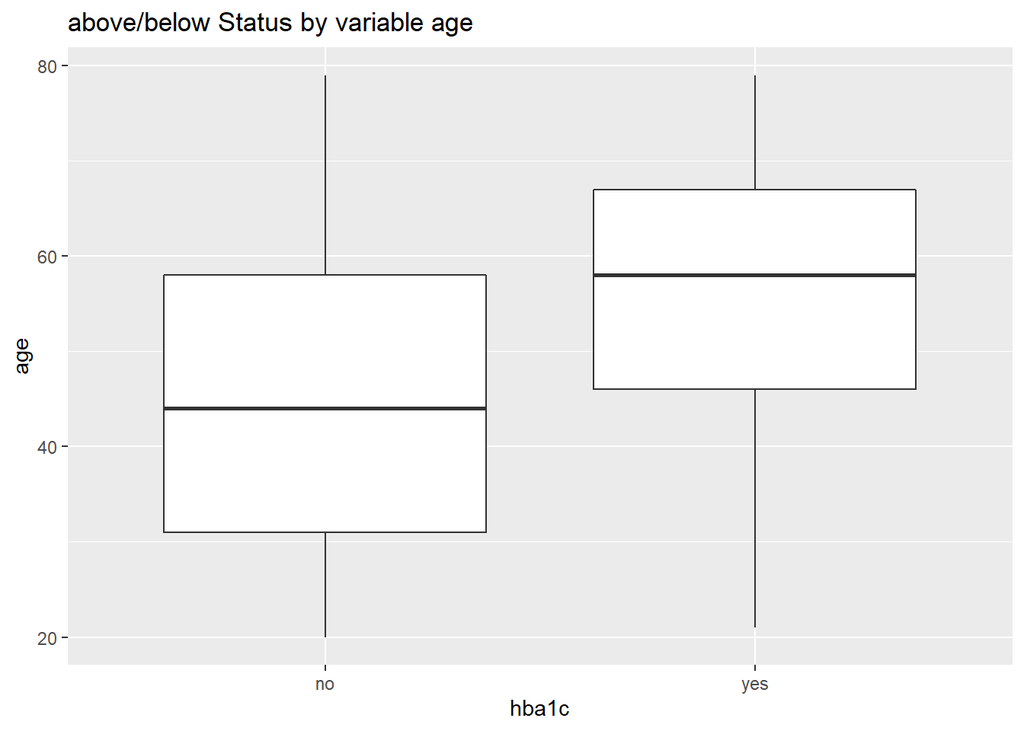

```r
#box plot above vs below bmi
ggplot(data = impute1, aes(x = factor(hba1cCutoffFactor), y = age)) +
  geom_boxplot() +
  labs(title = "above/below Status by variable age") +
  labs(x = "hba1c")
```

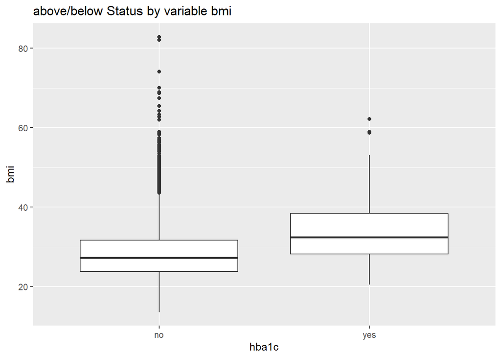

```r
#box plot above vs below age
ggplot(data = impute1, aes(x = factor(hba1cCutoffFactor), y = bmi)) +
  geom_boxplot() +
  labs(title = "above/below Status by variable bmi") +
  labs(x = "hba1c")
```

## Random forest classifier

### Train and Test Set

- Using the data set with all 5 multiple imputations (imputeLong) to increase n

```r
# Split into Train and Validation sets
# Training Set : Validation Set = 70 : 30 (random)
set.seed(619)
train <- sample(nrow(imputeLong), 0.7*nrow(imputeLong), replace = FALSE)
trainSet <- imputeLong[train,]
testSet <- imputeLong[-train,]
#summary(TrainSet)
#summary(ValidSet)
```

### Results of Random Forest

```r
#factors significant in bivariate analysis
nhanesRF <- randomForest(hba1cCutoffFactor ~ age + race + education + PIR + bmi + insurance + foodSecure + totKcal + totProt + totCarb + totSugr + totFat + diet, data = trainSet, importance = TRUE)
nhanesRF
```

```
##
## Call:
##  randomForest(formula = hba1cCutoffFactor ~ age + race + education +      PIR + bmi + insurance + foodSecure + totKcal + totProt +      totCarb + totSugr + totFat + diet, data = trainSet, importance = TRUE)
##                Type of random forest: classification
##                      Number of trees: 500
## No. of variables tried at each split: 3
##
##         OOB estimate of  error rate: 0.47%
## Confusion matrix:
##        no yes   class.error
## no  22632   2 0.00008836264
## yes   106 475 0.18244406196
```

```r
nhanesRF$importance
```

```
##                     no        yes MeanDecreaseAccuracy MeanDecreaseGini
## age        0.014458932 0.40380362          0.024210438        116.14789
## race       0.010268439 0.30047804          0.017537435         54.90022
## education  0.006328508 0.19512387          0.011057085         39.58542
## PIR        0.005741501 0.18482153          0.010238447         44.26545
## bmi        0.013267018 0.41744008          0.023397602        152.56936
## insurance  0.001677071 0.04755306          0.002824153         14.11301
## foodSecure 0.003750330 0.10225539          0.006213488         36.35857
## totKcal    0.020700740 0.18865957          0.024902645        120.38012
## totProt    0.013124202 0.18611076          0.017451322        128.64973
## totCarb    0.016817834 0.17448572          0.020767873        119.54479
## totSugr    0.012074805 0.17334510          0.016115944        122.08952
## totFat     0.014714244 0.18621095          0.019015413        126.85139
## diet       0.005287332 0.15173024          0.008947169         40.02254
```

```r
# Predicting on Validation set
nhanesRFPrediction <- predict(nhanesRF, testSet, type = "class")
table(nhanesRFPrediction)
```

```
## nhanesRFPrediction
##   no  yes
## 9726  224
```

```r
# Checking classification accuracy
mean(nhanesRFPrediction == testSet$hba1cCutoffFactor)
```

```
## [1] 0.9963819
```

```r
table(nhanesRFPrediction, testSet$hba1cCutoffFactor)
```

```
##
## nhanesRFPrediction   no  yes
##                no  9691   35
##                yes    1  223
```

# Limitations

The NHANES data only measures HbA1c and glucose (not included in this study) once. However, some studies indicate that confirmatory testing may be required to prevent over-estimation of UDM in the population (i.e. a single test may be an anomoloy) (7). Furthermore, as is always the case when working with NHANES data, the data are cross-sectional, thus no causal inference can be made without temporality. Self-reported data may be unreliable, including self-reported diabetes diagnosis and 24-hour dietary recalls. Specifically with dietary recall data, social-desireability bias may play an important role. These data lacked information about the geographical distribution of the cases. Prior research indicates that geographical region plays an important role in the diabetes epidemic. Yet, location information is restricted in this databases for protection of the participants, and is only accessible with an application to NHANES, which is beyond the scope of this project. Finally, with the models, the data had imbalanced classes for the semi-rare event of UDM (about 2% of the undiagnosed sample), which may make models unreliable without adjusting for imbalance. Adjustment for imbalanced was not done in this project.

# Conclusions

# References

1. Stokes, A., & Preston, S. H. (2017). The contribution of rising adiposity to the increasing prevalence of diabetes in the United States. Preventive Medicine, 101, 91-95. doi:https://doi.org/10.1016/j.ypmed.2017.05.031
2. Dall TM, Yang W, Halder P, Pang B, Massoudi M, Wintfeld N et al. The Economic Burden of Elevated Blood Glucose Levels in 2012: Diagnosed and Undiagnosed Diabetes, Gestational Diabetes Mellitus, and Prediabetes. Diabetes Care. 2014;37(12):3172-9. doi:10.2337/dc14-1036.
3. Centers for Disease Control and Prevention. National Diabetes Statistics Report, 2017. Atlanta, GA: Centers for Disease Control and Prevention, US Department of Health and Human Services; 2017.
4. US Centers for Disease Control and Prevention, & National Center for Health Statistics. (2014). National health and nutrition examination survey (NHANES) data. In. https://wwwn.cdc.gov/nchs/nhanes/Default.aspx: U.S. Department of Health and Human Services.
5. Johnson, C. L., Dohrmann, S. M., Burt, V. L., & Mohadjer, L. K. (2014). National Health and Nutrition Examination Survey: Sample design, 2011–2014. Vital Health Statistics, Series 2(162), 1-33.
6. Kavakiotis, I., Tsave, O., Salifoglou, A., Maglaveras, N., Vlahavas, I., & Chouvarda, I. (2017). Machine Learning and Data Mining Methods in Diabetes Research. Computational and Structural Biotechnology Journal, 15, 104-116. doi:https://doi.org/10.1016/j.csbj.2016.12.005
7. Geiss LS, Bullard KM, Brinks R, Gregg EW. Considerations in Epidemiologic Definitions of Undiagnosed Diabetes. Diabetes Care. 2018;41(9):1835-8. doi:10.2337/dc17-1838.